# DS 202 - Homework #2

## Swiss Banknotes

1. Download the RMarkdown file with these homework instructions to use as a template for your work. Make sure to replace “Your Name” in the YAML with your name.
2. The R package `mclust` contains a data set called `banknote`, consisting of (physical) measurements on 200 Swiss bank notes, 100 of which are genuine, while the other half is counterfeit. Load this data set (you might have to install the package) using the code below.

```r
# install.packages("mclust")
library(mclust) # if this throws an error of the form 'there is no package called mcmclust', uncomment the line above, run it once, then comment the line out again and run the code chunk again.
data(banknote)
```

3. (1 pt) Use one of our object inspecting functions and interpret the result in the data that you see.

   ```r
   ?banknote
   head(banknote)
   ```

   ```
   ##    Status Length  Left Right Bottom  Top Diagonal
   ## 1 genuine  214.8 131.0 131.1    9.0  9.7    141.0
   ## 2 genuine  214.6 129.7 129.7    8.1  9.5    141.7
   ## 3 genuine  214.8 129.7 129.7    8.7  9.6    142.2
   ## 4 genuine  214.8 129.7 129.6    7.5 10.4    142.0
   ## 5 genuine  215.0 129.6 129.7   10.4  7.7    141.8
   ## 6 genuine  215.7 130.8 130.5    9.0 10.1    141.4
   ```

   ```r
   summary(banknote)
   ```

   ```
   ##          Status        Length           Left           Right
   ##  counterfeit:100   Min.   :213.8   Min.   :129.0   Min.   :129.0
   ##  genuine    :100   1st Qu.:214.6   1st Qu.:129.9   1st Qu.:129.7
   ##                    Median :214.9   Median :130.2   Median :130.0
   ##                    Mean   :214.9   Mean   :130.1   Mean   :130.0
   ##                    3rd Qu.:215.1   3rd Qu.:130.4   3rd Qu.:130.2
   ##                    Max.   :216.3   Max.   :131.0   Max.   :131.1
   ##      Bottom            Top           Diagonal
   ##  Min.   : 7.200   Min.   : 7.70   Min.   :137.8
   ##  1st Qu.: 8.200   1st Qu.:10.10   1st Qu.:139.5
   ##  Median : 9.100   Median :10.60   Median :140.4
   ##  Mean   : 9.418   Mean   :10.65   Mean   :140.5
   ##  3rd Qu.:10.600   3rd Qu.:11.20   3rd Qu.:141.5
   ##  Max.   :12.700   Max.   :12.30   Max.   :142.4
   ```

- The ?banknote function gives more information about the banknote data frame. It tells me a source and description of the data and also provides information on the variables within the data frame, including:
  - Status - whether or not the banknote is genuine
  - Length - the length of the bill in mm
  - Left - width of the left edge in mm
  - Right - width of the right edge in mm
  - Bottom - bottom margin width in mm
  - Top - top margin width in mm
  - Diagonal - length of the diagonal in mm
- The head function shows me the values of the first few lines in the data frame.
- The summary function gives me a 5-number summary of each of the variables, as well as telling me that there are 100 genuine bills and 100 counterfeit bills in the data. For example, I can tell that the average for left and right width are around 130 mm, and can do this for all quantitative variables in the data set.
4. (1 pt) Use the package `ggplot2` to draw a barchart of `Status`. Map `Status` to the fill color of the barchart.

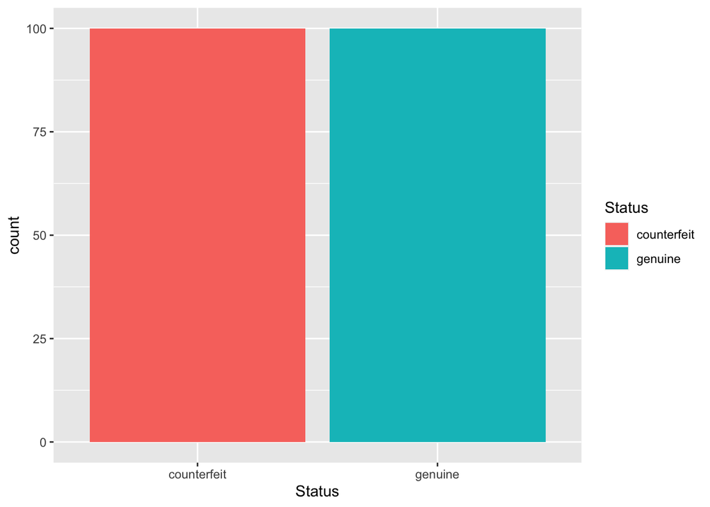

```r
library(ggplot2)
ggplot(data = banknote, aes(Status, fill = Status))+
  geom_bar()
```

5. (1 pt) Use the package `ggplot2` to draw a histogram of one of the variables in the dataset that shows a distinction between genuine and counterfeit banknotes. Use fill color to show this difference. Choose the binwidth such that there are no gaps in the middle range of the histogram.

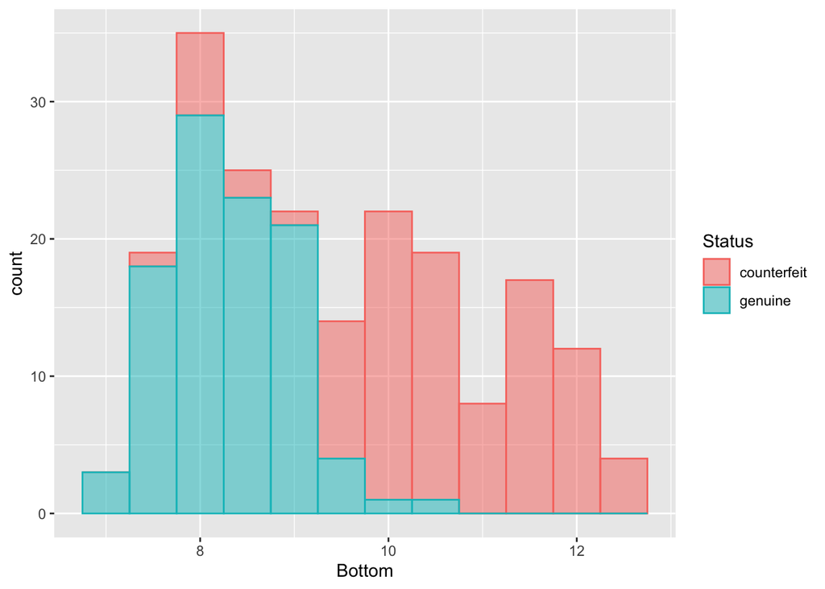

```r
ggplot(data = banknote, aes(x = Bottom, color = Status, fill = Status))+
  geom_histogram(alpha = 0.5, binwidth = 0.5)
```

6. (1 pt) Use the package `ggplot2` to draw a scatterplot of two (continuous) measurements, color by `Status`. Find a pair of measurements that allow you to separate perfectly between genuine and counterfeit banknotes.

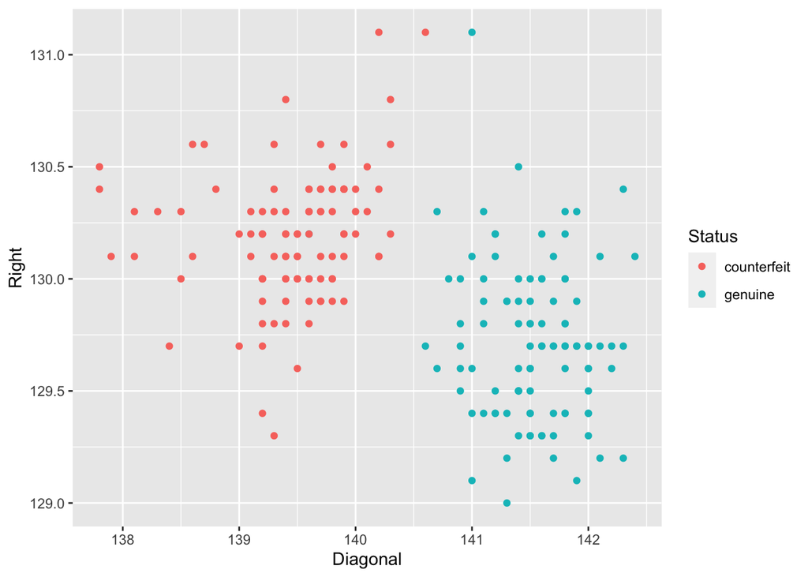

```r
ggplot(data = banknote, aes(x = Diagonal, y = Right, color = Status))+
  geom_point()
```

7. (4.5 pts) For each of the three figures above, write a three sentence summary, describing the:
   1. **structure of the plot**: what type of plot is it? Which variables are mapped to x, to y, and to the (fill) color?
   2. **main message of the plot**: what is your main finding, i.e. what do you want viewers to learn from the plot?
   3. **additional message**: point out anomalies or outliers, if there are any.

Plot #1: This bar chart has the status of the bills (counterfeit vs. genuine) mapped to the x-axis and represented in the color of the bars, as well as the counts mapped to the y-axis. This bar chart tells us that the distribution of bills in the data set is equal, with 100 counterfeit bills and 100 genuine bills. There are no outliers in the data.

Plot #2: This histogram has the bottom margin width mapped to the x-axis, the count for bottom margin width mapped to the y-axis, and is color-separated by the status of the bills (counterfeit vs. genuine). This shows that bills with a smaller bottom margin width are more likely to be genuine, while bills that have a larger bottom width are likely to be counterfeit. There are no major outliers in this data.

Plot #3: This scatterplot shows the relationship between the diagonal length, mapped on the x-axis, and the width of the right edge, mapped on the y-axis, with the color of the dots representing the status of the bills (real vs. counterfeit). This map shows that bills with a larger diagonal length (around 142 mm) and a smaller width of the right edge (around 129.5mm) are more likely to be genuine, while bills with a smaller diagonal length (around 139.5 mm) and a larger width of the right edge (around 130.25mm) are likely to be counterfeit. There is a diagonal cutoff line that clearly separates the counterfeit and genuine bills. There may be one outlier - a genuine bill with a diagonal of 141mm and a right edge of just over 131mm, but this is not a major outlier and does not have an impact on the conclusions of the data.

8. (1.5 pts) Ensure that your submission is reproducible. We will load your Rmd file into RStudio and knit it. This should match your submitted html/word file

For the submission: submit your solution in an R Markdown file. Also submit the corresponding html/word file with it.